# Analisi - FINAL

Full statistical analysis and plots

Mathilde Josserand [mathilde.josserand@gmail.fr], Elena Eccher [elena.eccher-1@unitn.it]

Fri Jun 30 14:36:58 2023

# Cards

Results and Plots for Ordering Cards Task

## Ordering Tasks

Here qualitative analysis of spatial arrangements chosen by participants

Percent of disposition_narrowed

| exp | shape | sum_total | percent_total |
| --- | --- | --- | --- |
| Himba Adults 2021 | H Line | 60 | 74.074074 |
| Himba Adults 2021 | No-shape | 15 | 18.518518 |
| Himba Adults 2021 | Non Linear | 3 | 3.703704 |
| Himba Adults 2021 | Other Linear | 3 | 3.703704 |
| Himba Adults 2022 | H Line | 70 | 84.337349 |
| Himba Adults 2022 | No-shape | 7 | 8.433735 |
| Himba Adults 2022 | Non Linear | 0 | 0.000000 |
| Himba Adults 2022 | Other Linear | 6 | 7.228916 |
| Italian Adults | H Line | 38 | 80.851064 |
| Italian Adults | No-shape | 0 | 0.000000 |
| Italian Adults | Non Linear | 8 | 17.021277 |
| Italian Adults | Other Linear | 1 | 2.127660 |
| Italian Preschoolers | H Line | 28 | 65.116279 |
| Italian Preschoolers | No-shape | 8 | 18.604651 |
| Italian Preschoolers | Non Linear | 6 | 13.953488 |
| Italian Preschoolers | Other Linear | 1 | 2.325581 |

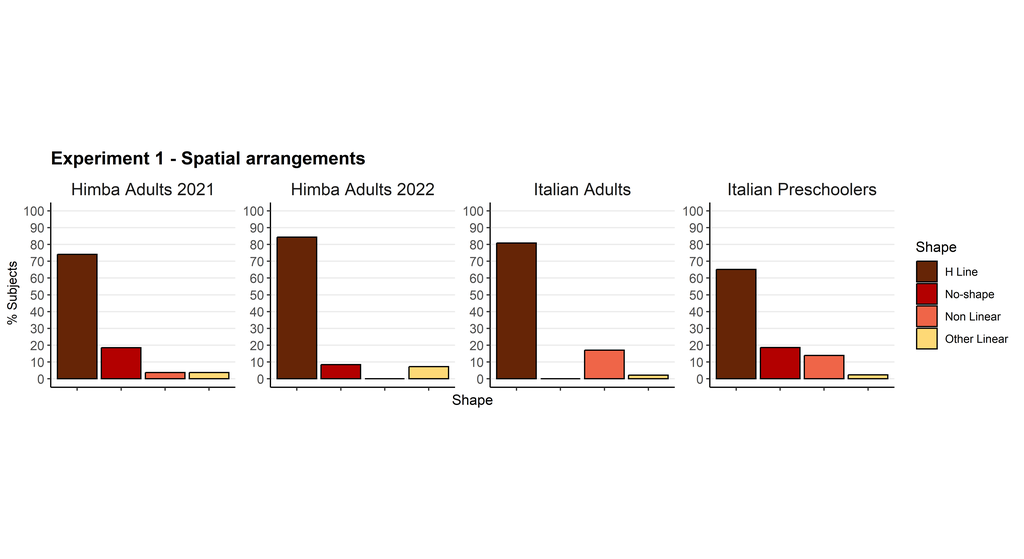

## Distributions of r per population

Here statistical analysis and plots for mapping disposition

Here me compute and measure the chance distribution to compare our real distributions with

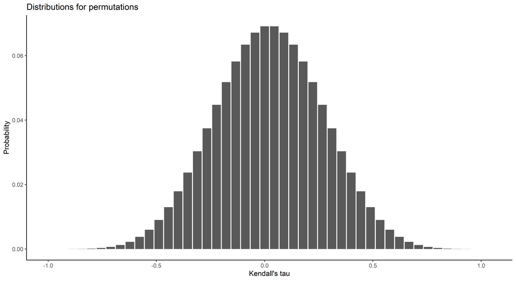

Here we test each real distribution of data versus the chance distribution, Two-sample Kolmogorov-Smirnov goodness-of-fit hypothesis test:

Two-sample Kolmogorov-Smirnov goodness-of-fit hypothesis test

|  | statistic | p.value | alternative | method | data.name |
| --- | --- | --- | --- | --- | --- |
| fit_test_adults | c(D = 0.956521739130435) | 0 | two-sided | Two-sample Kolmogorov-Smirnov test | nr_chance and nr_adults |
| fit_test_Himba2021 | c(D = 0.91304347826087) | 0 | two-sided | Two-sample Kolmogorov-Smirnov test | nr_chance and nr_Himba2021 |
| fit_test_Himba2022 | c(D = 0.91304347826087) | 0 | two-sided | Two-sample Kolmogorov-Smirnov test | nr_chance and nr_Himba2022 |
| fit_test_Preschooler | c(D = 0.956521739130435) | 0 | two-sided | Two-sample Kolmogorov-Smirnov test | nr_chance and nr_pres |

Here we test the mean of each distributions versus the chance level (Wilcoxon test, mu = 0):

Wilcoxon test against chance level, mu = 0

| exp | .y. | group1 | group2 | n | statistic | p | p.signif | y.position | groups | xmin | xmax |
| --- | --- | --- | --- | --- | --- | --- | --- | --- | --- | --- | --- |
| Himba Adults 2021 | cor | 1 | null model | 60 | 1067.0 | 0.257 | ns | 0.31072 | 1 , null model | 1 | 1 |
| Himba Adults 2022 | cor | 1 | null model | 70 | 1284.5 | 0.805 | ns | 0.20272 | 1 , null model | 1 | 1 |
| Italian Adults | cor | 1 | null model | 38 | 721.5 | 0.000 | **** | 1.10872 | 1 , null model | 1 | 1 |
| Italian Preschoolers | cor | 1 | null model | 28 | 261.0 | 0.188 | ns | 0.45172 | 1 , null model | 1 | 1 |

Quick plot visualization

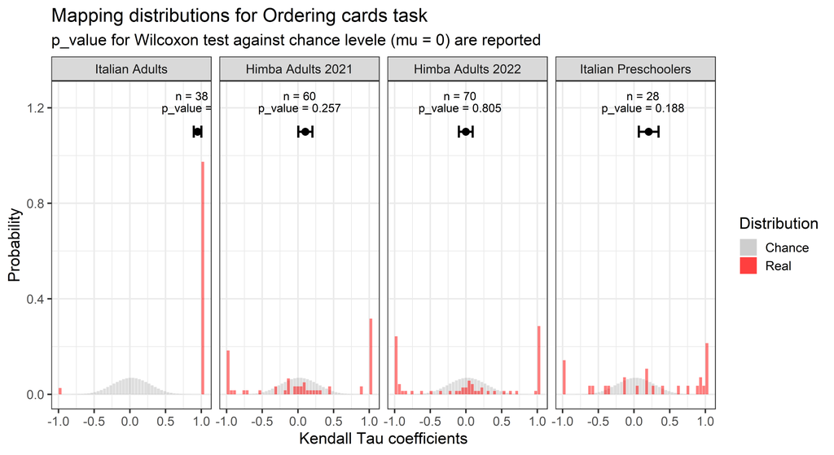

Here graph plotted with adjusted scales for better visualization

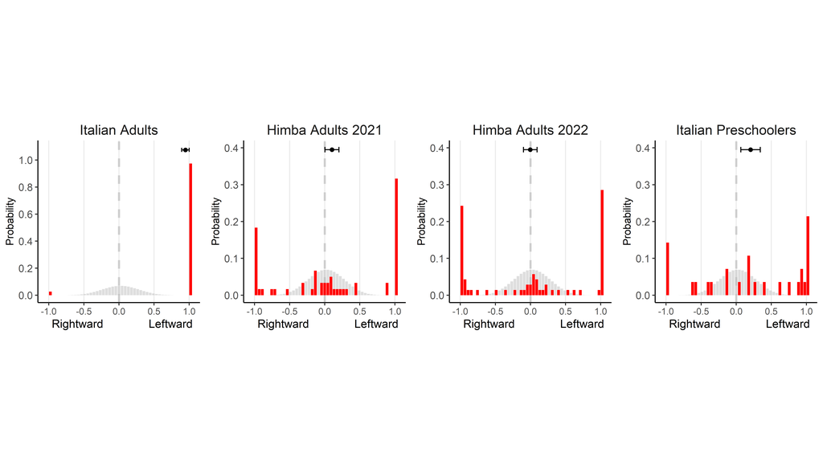

### Analysis - Kruskal–Wallis test

Here Kruskal–Wallis test for difference between population on mapping distributions

Quick boxplot visualization

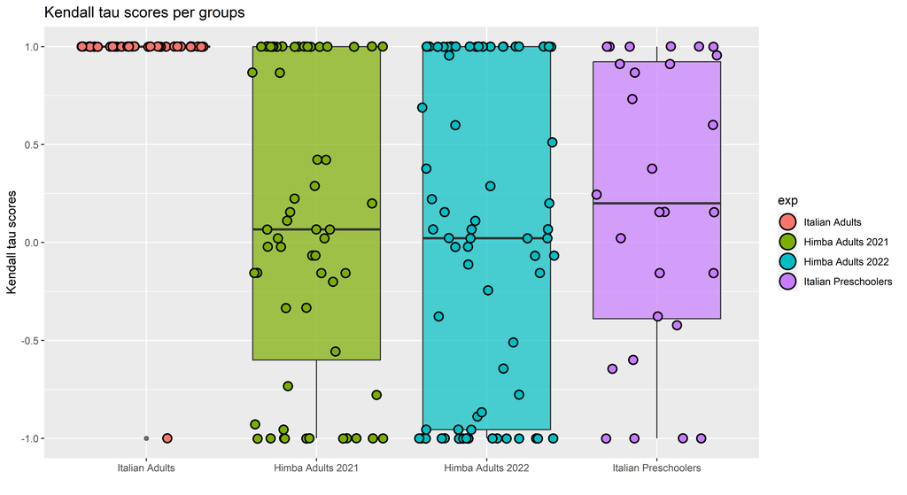

Statistical analysis

```
    Kruskal-Wallis rank sum test

data:  Mapping distirbution by Population Factor
Kruskal-Wallis chi-squared = 45.803, df = 3, p-value = 6.247e-10
```

```
    Pairwise comparisons using t tests with pooled SD

data:  Pairwise comparison for Population

                     Italian Adults Himba Adults 2021 Himba Adults 2022
Himba Adults 2021    1.5e-07        -                 -
Himba Adults 2022    2.6e-09        0.48              -
Italian Preschoolers 9.6e-05        0.54              0.29

P value adjustment method: BH
```

Adults are different from Himba and preschooler, but preschooler and Himba are not between eachother

# Numerosity Task

## Inverse efficiency

Looking at the distribution of the inverse efficiency (with target stimuli and correct answer only):

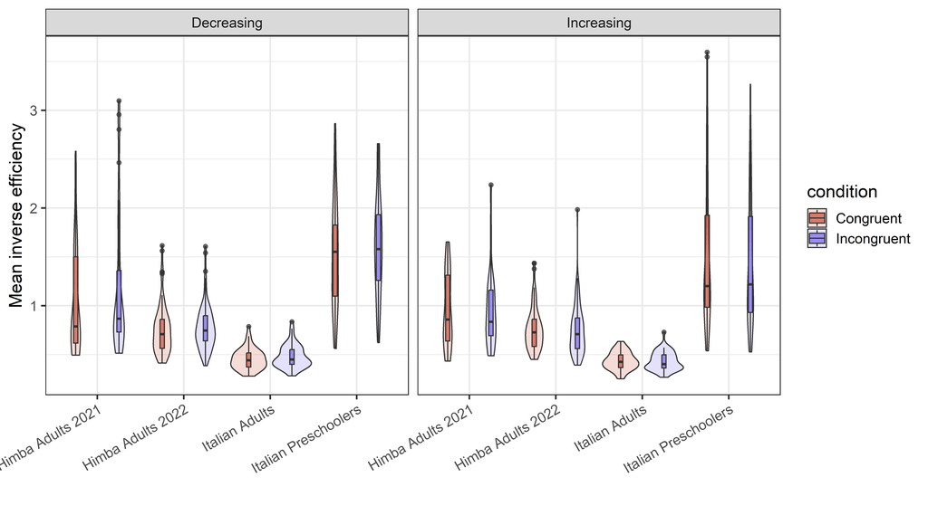

Plotting mean values and Standard Error of the mean

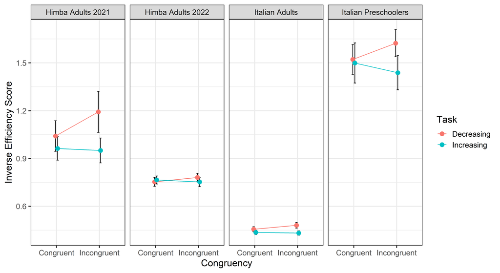

### Himba 2021 - ANOVA analysis

Here we compute ANOVA analysis for only Himba 2021, as they were the only group to perform the task with a between design for Task Istructions

```
ANOVA Table (type III tests)

                        Effect DFn DFd     F     p p<.05   ges
1            Task_Instructions   1  57 1.308 0.258       0.021
2                   Congruency   1  57 3.520 0.066       0.004
3 Task_Instructions:Congruency   1  57 4.901 0.031     * 0.006
```

| Task | .y. | group1 | group2 | n1 | n2 | statistic | df | p | p.adj | p.adj.signif |
| --- | --- | --- | --- | --- | --- | --- | --- | --- | --- | --- |
| Decreasing | invefi | Congruent | Incongruent | 33 | 33 | -2.7623962 | 32 | 0.005 | 0.005 | ** |
| Increasing | invefi | Congruent | Incongruent | 26 | 26 | 0.2722118 | 25 | 0.606 | 0.606 | ns |

### All experiments together (except Himbas 2021)

**Experiment & Group & condition**:

Note that *experiment* variable is between subject, while *group* and *condition* variables are within subject.

```
ANOVA Table (type III tests)

                                    Effect DFn DFd       F        p p<.05
1                               Population   2 160 134.910 4.64e-35     *
2                        Task_Instructions   1 160   3.674 5.70e-02
3                               Congruency   1 160   1.379 2.42e-01
4             Population:Task_Instructions   2 160   1.216 2.99e-01
5                    Population:Congruency   2 160   0.129 8.79e-01
6             Task_Instructions:Congruency   1 160  11.397 9.23e-04     *
7 Populations:Task_Instructions:Congruency   2 160   3.074 4.90e-02     *
       ges
1 5.54e-01
2 4.00e-03
3 2.99e-04
4 3.00e-03
5 5.59e-05
6 3.00e-03
7 1.00e-03
```

Pairwise Group Level

| .y. | group1 | group2 | n1 | n2 | p | p.signif | p.adj | p.adj.signif |
| --- | --- | --- | --- | --- | --- | --- | --- | --- |
| invefi | Himba Adults 2022 | Italian Adults | 312 | 188 | 0 | **** | 0 | **** |
| invefi | Himba Adults 2022 | Italian Preschoolers | 312 | 152 | 0 | **** | 0 | **** |
| invefi | Italian Adults | Italian Preschoolers | 188 | 152 | 0 | **** | 0 | **** |

Pairwise Interaction ~ Less alternative

| Task | exp | .y. | group1 | group2 | n1 | n2 | statistic | df | p | p.adj | p.adj.signif |
| --- | --- | --- | --- | --- | --- | --- | --- | --- | --- | --- | --- |
| Decreasing | Himba Adults 2022 | invefi | Congruent | Incongruent | 78 | 78 | -1.5763882 | 77 | 0.060000 | 0.060000 | ns |
| Decreasing | Italian Adults | invefi | Congruent | Incongruent | 47 | 47 | -3.6607548 | 46 | 0.000323 | 0.000323 | *** |
| Decreasing | Italian Preschoolers | invefi | Congruent | Incongruent | 38 | 38 | -2.3161023 | 37 | 0.013000 | 0.013000 | * |
| Increasing | Himba Adults 2022 | invefi | Congruent | Incongruent | 78 | 78 | 0.7723618 | 77 | 0.779000 | 0.779000 | ns |
| Increasing | Italian Adults | invefi | Congruent | Incongruent | 47 | 47 | 0.6758916 | 46 | 0.749000 | 0.749000 | ns |
| Increasing | Italian Preschoolers | invefi | Congruent | Incongruent | 38 | 38 | 0.9667701 | 37 | 0.830000 | 0.830000 | ns |

## Congruency effect IE

Shapiro Test for normal distribution

| Task | exp | variable | statistic | p |
| --- | --- | --- | --- | --- |
| Decreasing | Italian Adults | congruencyEffect_IE | 0.9231628 | 0.0043124 |
| Increasing | Italian Adults | congruencyEffect_IE | 0.9919664 | 0.9850506 |
| Decreasing | Himba Adults 2021 | congruencyEffect_IE | 0.9742753 | 0.6064611 |
| Increasing | Himba Adults 2021 | congruencyEffect_IE | 0.9682329 | 0.5780617 |
| Decreasing | Himba Adults 2022 | congruencyEffect_IE | 0.9789116 | 0.2224942 |
| Increasing | Himba Adults 2022 | congruencyEffect_IE | 0.9796050 | 0.2448950 |
| Decreasing | Italian Preschoolers | congruencyEffect_IE | 0.9566606 | 0.1476164 |
| Increasing | Italian Preschoolers | congruencyEffect_IE | 0.9377940 | 0.0355469 |

Test versus chance level

| Task | exp | .y. | group1 | group2 | n | statistic | p | p.signif | y.position | groups | x | xmin | xmax | Stat_test |
| --- | --- | --- | --- | --- | --- | --- | --- | --- | --- | --- | --- | --- | --- | --- |
| Decreasing | Himba Adults 2021 | congruencyEffect_IE | 1 | null model | 33 | 3.1294419 | 3.72e-03 | ** | 0.0780 | 1 , null model | 1 | 1 | 1 | T-test |
| Decreasing | Himba Adults 2022 | congruencyEffect_IE | 1 | null model | 78 | 2.2673195 | 2.62e-02 | * | 0.0410 | 1 , null model | 1 | 1 | 1 | T-test |
| Decreasing | Italian Preschoolers | congruencyEffect_IE | 1 | null model | 38 | 2.8244021 | 7.59e-03 | ** | 0.0660 | 1 , null model | 1 | 1 | 1 | T-test |
| Increasing | Italian Adults | congruencyEffect_IE | 1 | null model | 47 | -0.6720740 | 5.05e-01 | ns | 0.0110 | 1 , null model | 2 | 2 | 2 | T-test |
| Increasing | Himba Adults 2021 | congruencyEffect_IE | 1 | null model | 26 | -0.2489187 | 8.05e-01 | ns | 0.0230 | 1 , null model | 2 | 2 | 2 | T-test |
| Increasing | Himba Adults 2022 | congruencyEffect_IE | 1 | null model | 78 | -1.5750126 | 1.19e-01 | ns | 0.0030 | 1 , null model | 2 | 2 | 2 | T-test |
| Decreasing | Italian Adults | congruencyEffect_IE | 1 | null model | 47 | 918.0000000 | 9.67e-05 | **** | 0.0346 | 1 , null model | 1 | 1 | 1 | Wilcoxon Test |
| Increasing | Italian Preschoolers | congruencyEffect_IE | 1 | null model | 38 | 314.0000000 | 4.21e-01 | ns | 0.0046 | 1 , null model | 2 | 2 | 2 | Wilcoxon Test |

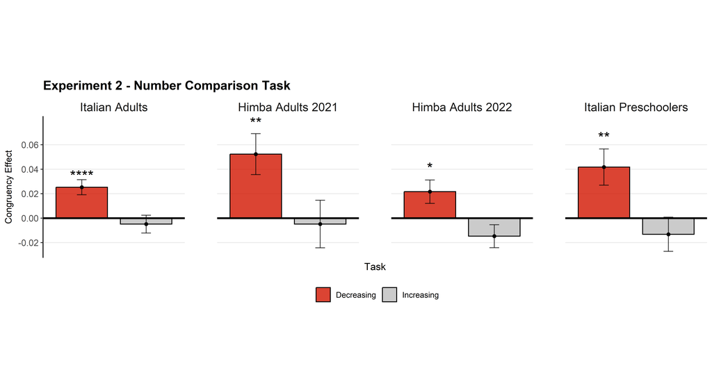

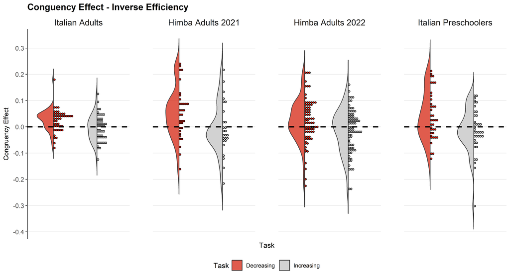

Here we perform statistical analysis to verify whether the Congruency Effect vary across groups and task (no Himba 2021)

Anova for Congruency Effect (No Himba 2021)

| Effect | DFn | DFd | F | p | p<.05 | ges |
| --- | --- | --- | --- | --- | --- | --- |
| exp | 2 | 160 | 0.576 | 5.63e-01 |  | 0.004 |
| Task | 1 | 160 | 21.164 | 8.50e-06 | * | 0.062 |
| exp:Task | 2 | 160 | 0.599 | 5.51e-01 |  | 0.004 |

Himba 2021 tested separately as Task Instructions is a Between factor for them:

```
    Welch Two Sample t-test

data:  Congruency Effect by Task Instructions in Himba 2021
t = 2.2301, df = 53.026, p-value = 0.02999
alternative hypothesis: true difference in means is not equal to 0
95 percent confidence interval:
 0.005751993 0.108569499
sample estimates:
   mean of x    mean of y
 0.052325174 -0.004835573
```

# Correlation between Task

Here we verify Independence of the two tasks. If the DV of one task correlates with the DV of the other it probably means that the Tasks are measuring the same undergoing mechanism, we do no expect them to be not correlated.

Italian Adults are removed from the analysis due to the skewness of their data (~98% of participants have Kendall tau score equal to 1)

Correlation analysis

```
    Kendall's rank correlation tau

data:  Correlation between Congruency Effect in Decreasing Task and Kendall Tau correlation scores from Ordering cards task
z = -1.0676, p-value = 0.2857
alternative hypothesis: true tau is not equal to 0
sample estimates:
        tau
-0.07273998
```

```
    Kendall's rank correlation tau

data:  Correlation between Congruency Effect in Increasing Task and Kendall Tau correlation scores from Ordering cards task
z = 0.25472, p-value = 0.7989
alternative hypothesis: true tau is not equal to 0
sample estimates:
       tau
0.01729175
```

Correlation Plot between the two tasks measures, for each Task instructions

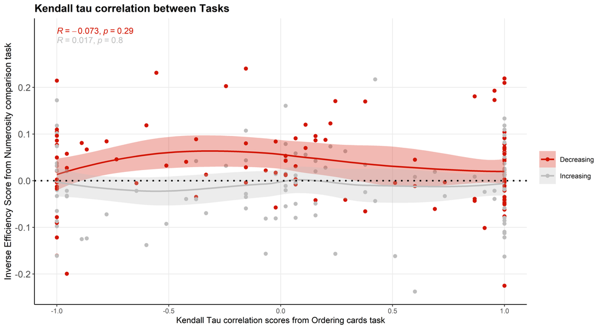